# **AnThroM**

## 9 One model across the networks

## 9.1 Theory-of-Mind:

All ToM regions combined:

```r
tom <- brm(formula = cent_contrast ~ cent_IDAQ + cent_IDAQ2,
      data = DF.roi %>% filter(network == "tom"),
      family = gaussian,
      chains = 4,
      iter = 4000,
      seed = 42, #so the model is reproducible
      file = "tom.RDS")
```

```
recompiling to avoid crashing R session
```

[output not shown]

Summary:

```r
summary(tom)
```

```
 Family: gaussian
  Links: mu = identity; sigma = identity
Formula: cent_contrast ~ cent_IDAQ + cent_IDAQ2
   Data: DF.roi %>% filter(network == "tom") (Number of observations: 648)
Samples: 4 chains, each with iter = 4000; warmup = 2000; thin = 1;
         total post-warmup samples = 8000

Population-Level Effects:
           Estimate Est.Error l-95% CI u-95% CI Rhat Bulk_ESS Tail_ESS
Intercept      0.05      0.05    -0.04     0.15 1.00     8563     6388
cent_IDAQ      0.04      0.04    -0.04     0.12 1.00     8235     5591
cent_IDAQ2    -0.05      0.03    -0.11    -0.00 1.00     8278     6444

Family Specific Parameters:
      Estimate Est.Error l-95% CI u-95% CI Rhat Bulk_ESS Tail_ESS
sigma     1.00      0.03     0.94     1.05 1.00     9276     5605

Samples were drawn using sampling(NUTS). For each parameter, Bulk_ESS
and Tail_ESS are effective sample size measures, and Rhat is the potential
scale reduction factor on split chains (at convergence, Rhat = 1).
```

Posterior summary:

```r
posterior_summary(tom)
```

```
                  Estimate  Est.Error          Q2.5         Q97.5
b_Intercept     0.05185312 0.04735636   -0.04164000    0.14518239
b_cent_IDAQ     0.04075624 0.03942079   -0.03653057    0.11819703
b_cent_IDAQ2   -0.05275223 0.02713755   -0.10531989   -0.00148772
sigma           0.99620933 0.02778562    0.94304512    1.05299219
lp__         -922.27993455 1.36794623 -925.66288745 -920.54979959
```

Posterior plots:

```r
tom_all <- bind_rows("all" = as_tibble(as.mcmc(tom,  pars = c("b_cent_IDAQ", "b_cent_IDAQ2"), combine_chains = TRUE), .id = "network")
```

[output not shown]

## 9.2 Pain Matrix:

```r
pain <- brm(formula = cent_contrast ~ cent_IDAQ + cent_IDAQ2,
      data = DF.roi %>% filter(network == "pain"),
      family = gaussian,
      chains = 4,
      iter = 4000,
      seed = 42, #so the model is reproducible
      file = "pain.RDS")
```

```
recompiling to avoid crashing R session
```

[output not shown]

Summary:

```r
summary(pain)
```

```
 Family: gaussian
  Links: mu = identity; sigma = identity
Formula: cent_contrast ~ cent_IDAQ + cent_IDAQ2
   Data: DF.roi %>% filter(network == "pain") (Number of observations: 756)
Samples: 4 chains, each with iter = 4000; warmup = 2000; thin = 1;
         total post-warmup samples = 8000

Population-Level Effects:
           Estimate Est.Error l-95% CI u-95% CI Rhat Bulk_ESS Tail_ESS
Intercept     -0.01      0.04    -0.10     0.08 1.00     8949     6471
cent_IDAQ      0.00      0.04    -0.07     0.07 1.00     8195     5869
cent_IDAQ2     0.01      0.03    -0.04     0.06 1.00     7997     6628

Family Specific Parameters:
      Estimate Est.Error l-95% CI u-95% CI Rhat Bulk_ESS Tail_ESS
sigma     1.00      0.03     0.95     1.05 1.00     7882     5243

Samples were drawn using sampling(NUTS). For each parameter, Bulk_ESS
and Tail_ESS are effective sample size measures, and Rhat is the potential
scale reduction factor on split chains (at convergence, Rhat = 1).
```

Posterior summary:

```r
posterior_summary(pain)
```

```
                  Estimate  Est.Error          Q2.5         Q97.5
b_Intercept  -6.669523e-03 0.04438327 -9.638809e-02  7.976383e-02
b_cent_IDAQ   3.397100e-03 0.03617522 -6.767533e-02  7.318044e-02
b_cent_IDAQ2  6.582722e-03 0.02542831 -4.243062e-02  5.622728e-02
sigma         9.989711e-01 0.02626822  9.484499e-01  1.052677e+00
lp__         -1.077092e+03 1.40501218 -1.080615e+03 -1.075320e+03
```

Posterior plots:

[output not shown]

[output cut: 990 more lines]

## 9.3 Posterior plots for the two networks:

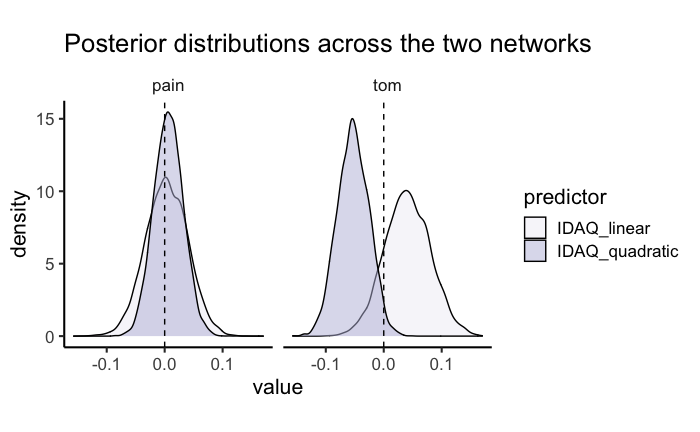

# 10. Control analyses

## 10.1 Theory-of-Mind network

Update the models by removing the 16 participants that completed a different version of the IDAQ (1-10). We create a function to do this:

```r
update_model <- function(model_old, region){
  model_new <- update(model_old, newdata = DF.roi %>% filter(roi == region & !sub %in% sub_ex), seed = 41)

  m1 <- posterior_summary(model_old)[c("b_cent_IDAQ", "b_cent_IDAQ2") , "Estimate"]
  m2 <- posterior_summary(model_new)[c("b_cent_IDAQ", "b_cent_IDAQ2") , "Estimate"]

  tibble(bias = round(100*((m1-m2)/m2), 2), predictor = c("b_cent_IDAQ", "b_cent_IDAQ2"))
}
```

Calculate the difference (bias) per region:

| bias | predictor |
| --- | --- |
| -104.29 | b_cent_IDAQ |
| 21.09 | b_cent_IDAQ2 |

```r
model_network <- LOO(tom, pain)
```

[output not shown]

1. Across all ToM ROIs
- Compare linear model vs. quadratic model; is there evidence for one, or for Null?
- Fit the model, predict values, test sensitivity/fit
2. For each ToM ROI
- Compare linear model vs. quadratic model; is there evidence for one, or for Null?
- Fit the model, predict values, test sensitivity/fit

(3. control across all ROIs - pain) (4. control for each pain ROI)

Add seed at the end!

```r
plot(conditional_effects(ltpj),points = TRUE)

posterior_plots(ltpj)
?conditional_effects
test <- as.matrix(rtpj)

library("broom")
library("rstanarm")
library("tidyverse")


fit <- stan_glm(mpg ~ ., data = mtcars)
summary(fit)
posterior <- as.matrix(fit)

plot_title <- ggtitle("Posterior distributions",
                      "with medians and 80% intervals")
mcmc_areas(posterior,
           pars = c("cyl", "drat", "am", "wt"),
           prob = 0.8) + plot_title

posterior <- as.matrix(test2)
plot_title <- ggtitle("Posterior distributions",
                      "with medians and 80% intervals")
mcmc_areas(posterior,
           pars = c("b_cent_IDAQS", "b_cent_IDAQ2S"),
           prob = 0.8) + plot_title
summary(test2)


color_scheme_set("red")
ppc_dens_overlay(y = fit$y,
                 yrep = posterior_predict(fit, draws = 50))

color_scheme_set("brightblue")
test %>%
  posterior_predict(draws = 500) %>%
  ppc_stat_grouped(y = b_cent_IDAQ2S,
                   stat = "median")
plot(test2)
plot(ltpj)
plot(prec)
plot(vmpfc)
plot(mmpfc)
plot(dmpfc)
```

```r
pp_check(rtpj, nsamples = 100) #maximal model


library(doBy)
library(brms)
library(easystats)
library(tidyverse)

rope_range(test) # determine the ROPE range

testR <- bayestestR::equivalence_test(test, range = c(-0.1, 0.1), ci = 0.95) # assert the null
testR <- testR[-c(3),]

plot(testR) + theme_abyss() + scale_fill_flat() # plot the decision on H0


describe_posterior(
  rtpj,
  effects = "all",
  component = "all",
  test = c("p_direction", "p_significance"),
  centrality = "all"
)


library(bayestestR)

posterior <- distribution_gamma(10000, 1.5)  # Generate a skewed distribution
centrality <- point_estimate(posterior)  # Get indices of centrality
centrality
plot(centrality)
plot(rtpj)
```

```r
options("scipen"=10, "digits"=5)

tidy(rtpj) %>% slice(1:3) %>% mutate_if(is.double, round, digits = 5)


DF.test <- DF.roi %>%
  filter(roi == "rtpj")


reg.1 <- brm(formula = cent_contrast ~ cent_IDAQ + cent_IDAQ2,
             data = DF.test,
             family = gaussian)

plot(DF.test$cent_IDAQ2, DF.test$cent_IDAQ)


summary(reg.1)
plot(reg.1)
posterior_summary(reg.1)
prior_summary(reg.1)
pairs(reg.1) #look into this
plot(conditional_effects(reg.1), points = TRUE)

roi <- "rtpj"

reg.2 <- brm(formula = cent_contrast ~ cent_IDAQ + cent_IDAQ2,
             data = DF.roi %>% filter(roi == roi),
             family = gaussian,
             chains = 4,
             iter = 4000,
             seed = 42,
             file = paste0(roi, ".RDS"))
summary(reg.2)
tidy(rtpj) %>% slice(1:3) %>% mutate_if(is.double, round, digits = 2)


library("shinystan")

launch_shinystan(reg.1)
```

```r
reg.2 <- brm(formula = cent_contrast ~ (cent_IDAQ + I(cent_IDAQ^2)),
             data = DF.test)

  print(summary(fit_lin))
    me <- marginal_effects(fit_lin, "time") %>%
      plot(plot = FALSE) %>%
      getElement(1) +
      ylim(range(dat_tmp$rating, na.rm = TRUE) + c(-0.5, 0.5))
    plot(me)

    # quadratic model
    fit_quad <- run_model(
      brm(
        rating ~ (time + I(time^2)) +
          Age + Geschlecht + Erstbehandlung + diag +
          ((time + I(time^2)) | PATNR) + (1 | item),
        data = dat_tmp, family = fam,
        cores = cores, chains = chains
      ),
      path = paste0("models/fit_hyp1_", meas, "_", fam, "_quad")
    )
    print(summary(fit_quad))
    me <- marginal_effects(fit_quad, "time") %>%
      plot(plot = FALSE) %>%
      getElement(1) +
      ylim(range(dat_tmp$rating, na.rm = TRUE) + c(-0.5, 0.5))
    plot(me)
```

```r
# install.packages("rstanarm") #do not selet the one that needs complilation
library(rstan)
library(rstanarm)
library(ggplot2)
library(bayesplot)


# this option uses multiple cores if they're available
options(mc.cores = parallel::detectCores())

DF.test <- DF.roi %>%
  filter(roi == "rtpj")

glm_post1 <- stan_glm(cent_contrast~cent_IDAQ, data=DF.test, family=gaussian) #which family?
glm_post1 <- stan_glm(contrast~IDAQ + I(IDAQ^2), data=DF.test, family=gaussian) #does it need to be centered?

stan_trace(glm_post1, pars=c("(Intercept)","IDAQ","sigma"))
summary(glm_post1)
pp_check(glm_post1)

posterior_vs_prior(glm_post1, group_by_parameter = TRUE, pars=c("(Intercept)"))
posterior_vs_prior(glm_post1, group_by_parameter = TRUE, pars=c("cent_IDAQ","sigma"))


linear.model <-lm(DF.test$cent_contrast ~ DF.test$cent_IDAQ +I(DF.test$cent_IDAQ^2))
glm_fit <- glm(cent_contrast~cent_IDAQ +I(cent_IDAQ^2), data=DF.test, family=gaussian)
glm_fit <- glm(cent_contrast~cent_IDAQ, data=DF.test, family=gaussian)

summary(glm_fit)
summary(linear.model)

plot(DF.test$cent_contrast ~ DF.test$cent_IDAQ, pch=16, ylab = "Counts ", cex.lab = 1.3, col = "red")
abline(lm(DF.test$cent_contrast ~ DF.test$cent_IDAQ), col = "blue")


DF.test$cent_IDAQ2 <- DF.test$cent_IDAQ^2
quadratic.model <-lm(DF.test$cent_contrast ~ DF.test$cent_IDAQ + DF.test$cent_IDAQ2)
summary(quadratic.model)

idaqvalues <- seq(-40, 51, .1)
predictedcounts <- predict(quadratic.model,list(IDAQ=idaqvalues, IDAQ2=idaqvalues^2))
plot(DF.test$cent_contrast ~ DF.test$cent_IDAQ, pch=16, ylab = "Counts ", cex.lab = 1.3, col = "red")
lines(idaqvalues, predictedcounts, col = "darkgreen", lwd = 3)
```

```r
# OLD code: get fitted values
newdata = data.frame(dataset = levels(as.factor(DF.test$dataset)), itemnr = as.factor(DF.test$itemnr))
fit = fitted(mod1, newdata = newdata, re_formula = NA)
colnames(fit) = c('fit', 'se', 'lwr', 'upr')
df_plot = cbind(newdata, fit)
df_plot

obs = aggregate(value ~ dataset, DF.test, mean)

ggplot(df_plot, aes(x = dataset, y = fit)) +
  geom_violin(data=DF.test, aes(x=dataset, y=value), alpha=0.5, color="gray70", fill='gray95') +
  geom_jitter(data=obs, aes(x=dataset, y=value), alpha=0.3, position = position_jitter(width = 0.07)) +
  geom_errorbar(aes(ymin=lwr, ymax=upr), position=position_dodge(), size=1, width=.5) +
  geom_point(shape=21, size=4, fill='red') +
  xlab("") +
  theme_bw () +
  theme(panel.grid = element_blank())
```